# Classification Analysis – Wisconsin Breast Cancer Dataset

Abdul Samad Khan

2026-08-08

# 1. Introduction

This report investigates the use of supervised machine learning techniques for classifying breast tumours as either benign or malignant. The analysis uses the Wisconsin Breast Cancer Database, which contains measurements derived from breast cytology samples.

The objective is to develop and evaluate two classification approaches: Decision Trees and k-nearest neighbours (kNN). The models will be trained using a training dataset and evaluated using previously unseen test data. Hyperparameter tuning will also be undertaken to investigate whether model performance can be improved.

The analysis consists of four main stages. First, the dataset is explored and prepared for modelling, including the treatment of missing values and the conversion of the target variable into a categorical variable. Second, exploratory data analysis is conducted using summary statistics and visualisations to identify patterns in the predictor variables and their relationship with tumour class. Third, Decision Tree and kNN classification models are developed and tuned. Finally, the models are compared using appropriate classification performance measures and the results are discussed.

# 2. Dataset Description

The dataset used in this analysis is the Wisconsin Breast Cancer Database, originally obtained from the University of Wisconsin Hospitals. The dataset contains 699 observations and 10 predictor attributes, together with a categorical class variable indicating whether a tumour is benign or malignant.

The predictor variables describe characteristics of cell nuclei observed from breast cytology samples. Each of the predictor measurements has values ranging from 1 to 10, with higher values generally representing more pronounced abnormalities.

The variables are:

| Variable | Description |
| --- | --- |
| SampleCodeNumber | Identification number for the sample |
| ClumpThickness | Thickness of the cell clumps |
| UniformityCellSize | Uniformity of cell size |
| UniformityCellShape | Uniformity of cell shape |
| MarginalAdhesion | Marginal adhesion |
| SingleEpithelialCellSize | Size of single epithelial cells |
| BareNuclei | Proportion/appearance of bare nuclei |
| BlandChromatin | Bland chromatin |
| NormalNucleoli | Normal nucleoli |
| Mitoses | Rate of cell division |
| Class | Tumour classification: benign or malignant |

The class variable is coded as 2 for benign tumours and 4 for malignant tumours. The original dataset contains 458 benign observations (65.5%) and 241 malignant observations (34.5%). Sixteen observations contain a single missing predictor value, represented by “?”.

The dataset and accompanying documentation were obtained from the UCI Machine Learning Repository:

[UCI Machine Learning Repository – Breast Cancer Wisconsin Dataset](https://archive.ics.uci.edu/dataset/15/breast)

```r
# Load the Wisconsin Breast Cancer dataset
Cancer <- read.csv(
  "breast-cancer-wisconsin.data",
  header = FALSE,
  na.strings = "?"
)

# Assign meaningful column names
colnames(Cancer) <- c(
  "SampleCodeNumber",
  "ClumpThickness",
  "UniformityCellSize",
  "UniformityCellShape",
  "MarginalAdhesion",
  "SingleEpithelialCellSize",
  "BareNuclei",
  "BlandChromatin",
  "NormalNucleoli",
  "Mitoses",
  "Class"
)

head(Cancer)
```

```
##   SampleCodeNumber ClumpThickness UniformityCellSize UniformityCellShape
## 1          1000025              5                  1                   1
## 2          1002945              5                  4                   4
## 3          1015425              3                  1                   1
## 4          1016277              6                  8                   8
## 5          1017023              4                  1                   1
## 6          1017122              8                 10                  10
##   MarginalAdhesion SingleEpithelialCellSize BareNuclei BlandChromatin
## 1                1                        2          1              3
## 2                5                        7         10              3
## 3                1                        2          2              3
## 4                1                        3          4              3
## 5                3                        2          1              3
## 6                8                        7         10              9
##   NormalNucleoli Mitoses Class
## 1              1       1     2
## 2              2       1     2
## 3              1       1     2
## 4              7       1     2
## 5              1       1     2
## 6              7       1     4
```

## 2.1 Initial Data Inspection

The first step is to examine the structure and dimensions of the dataset. This helps confirm that the data have been imported correctly and allows the variable types and number of observations to be checked.

```r
# Number of observations and variables
dim(Cancer)
```

```
## [1] 699  11
```

```r
# Structure of the dataset
str(Cancer)
```

```
## 'data.frame':    699 obs. of  11 variables:
##  $ SampleCodeNumber        : int  1000025 1002945 1015425 1016277 1017023 1017122 1018099 1018561 1033078 1033078 ...
##  $ ClumpThickness          : int  5 5 3 6 4 8 1 2 2 4 ...
##  $ UniformityCellSize      : int  1 4 1 8 1 10 1 1 1 2 ...
##  $ UniformityCellShape     : int  1 4 1 8 1 10 1 2 1 1 ...
##  $ MarginalAdhesion        : int  1 5 1 1 3 8 1 1 1 1 ...
##  $ SingleEpithelialCellSize: int  2 7 2 3 2 7 2 2 2 2 ...
##  $ BareNuclei              : int  1 10 2 4 1 10 10 1 1 1 ...
##  $ BlandChromatin          : int  3 3 3 3 3 9 3 3 1 2 ...
##  $ NormalNucleoli          : int  1 2 1 7 1 7 1 1 1 1 ...
##  $ Mitoses                 : int  1 1 1 1 1 1 1 1 5 1 ...
##  $ Class                   : int  2 2 2 2 2 4 2 2 2 2 ...
```

```r
# Summary statistics
summary(Cancer)
```

```
##  SampleCodeNumber   ClumpThickness   UniformityCellSize UniformityCellShape
##  Min.   :   61634   Min.   : 1.000   Min.   : 1.000     Min.   : 1.000
##  1st Qu.:  870689   1st Qu.: 2.000   1st Qu.: 1.000     1st Qu.: 1.000
##  Median : 1171710   Median : 4.000   Median : 1.000     Median : 1.000
##  Mean   : 1071704   Mean   : 4.418   Mean   : 3.134     Mean   : 3.207
##  3rd Qu.: 1238298   3rd Qu.: 6.000   3rd Qu.: 5.000     3rd Qu.: 5.000
##  Max.   :13454352   Max.   :10.000   Max.   :10.000     Max.   :10.000
##
##  MarginalAdhesion SingleEpithelialCellSize   BareNuclei     BlandChromatin
##  Min.   : 1.000   Min.   : 1.000           Min.   : 1.000   Min.   : 1.000
##  1st Qu.: 1.000   1st Qu.: 2.000           1st Qu.: 1.000   1st Qu.: 2.000
##  Median : 1.000   Median : 2.000           Median : 1.000   Median : 3.000
##  Mean   : 2.807   Mean   : 3.216           Mean   : 3.545   Mean   : 3.438
##  3rd Qu.: 4.000   3rd Qu.: 4.000           3rd Qu.: 6.000   3rd Qu.: 5.000
##  Max.   :10.000   Max.   :10.000           Max.   :10.000   Max.   :10.000
##                                            NA's   :16
##  NormalNucleoli      Mitoses           Class
##  Min.   : 1.000   Min.   : 1.000   Min.   :2.00
##  1st Qu.: 1.000   1st Qu.: 1.000   1st Qu.:2.00
##  Median : 1.000   Median : 1.000   Median :2.00
##  Mean   : 2.867   Mean   : 1.589   Mean   :2.69
##  3rd Qu.: 4.000   3rd Qu.: 1.000   3rd Qu.:4.00
##  Max.   :10.000   Max.   :10.000   Max.   :4.00
##
```

## 2.2 Missing Value Analysis

The dataset documentation indicates that 16 observations contain a missing value. These missing values are represented by “?” in the original data. During import, these values were converted to `NA` so that they could be identified and handled appropriately.

```r
# Count missing values in each variable
missing_values <- colSums(is.na(Cancer))

missing_table <- data.frame(
  Variable = names(missing_values),
  MissingValues = as.numeric(missing_values)
)

missing_table
```

```
##                    Variable MissingValues
## 1          SampleCodeNumber             0
## 2            ClumpThickness             0
## 3        UniformityCellSize             0
## 4       UniformityCellShape             0
## 5          MarginalAdhesion             0
## 6  SingleEpithelialCellSize             0
## 7                BareNuclei            16
## 8            BlandChromatin             0
## 9            NormalNucleoli             0
## 10                  Mitoses             0
## 11                    Class             0
```

The total number of missing values can also be calculated:

```r
sum(is.na(Cancer))
```

```
## [1] 16
```

# 3. Exploratory Data Analysis

Exploratory data analysis is undertaken before model development to understand the distribution of the target variable and the characteristics of the predictor variables.

## 3.1 Distribution of Tumour Classes

```r
# Create a frequency table for the tumour classes
class_counts <- table(Cancer$Class)

class_counts
```

```
##
##   2   4
## 458 241
```

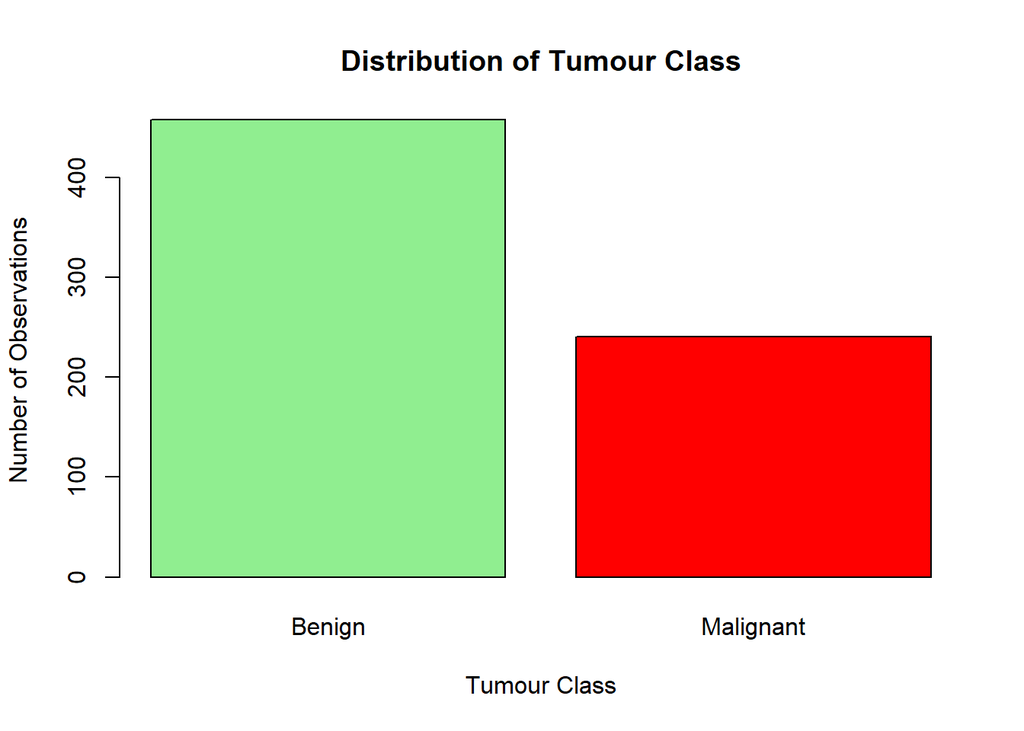

```r
# Display the class distribution using meaningful class labels
barplot(
  class_counts,
  main = "Distribution of Tumour Class",
  xlab = "Tumour Class",
  ylab = "Number of Observations",
  names.arg = c("Benign", "Malignant"),
  col = c("lightgreen", "red")
)
```

## 3.2 Summary Statistics of Predictor Variables

```r
# Select the nine predictor variables
predictors <- Cancer[, setdiff(names(Cancer), "Class")]

# Calculate descriptive statistics
summary(predictors)
```

```
##  SampleCodeNumber   ClumpThickness   UniformityCellSize UniformityCellShape
##  Min.   :   61634   Min.   : 1.000   Min.   : 1.000     Min.   : 1.000
##  1st Qu.:  870689   1st Qu.: 2.000   1st Qu.: 1.000     1st Qu.: 1.000
##  Median : 1171710   Median : 4.000   Median : 1.000     Median : 1.000
##  Mean   : 1071704   Mean   : 4.418   Mean   : 3.134     Mean   : 3.207
##  3rd Qu.: 1238298   3rd Qu.: 6.000   3rd Qu.: 5.000     3rd Qu.: 5.000
##  Max.   :13454352   Max.   :10.000   Max.   :10.000     Max.   :10.000
##
##  MarginalAdhesion SingleEpithelialCellSize   BareNuclei     BlandChromatin
##  Min.   : 1.000   Min.   : 1.000           Min.   : 1.000   Min.   : 1.000
##  1st Qu.: 1.000   1st Qu.: 2.000           1st Qu.: 1.000   1st Qu.: 2.000
##  Median : 1.000   Median : 2.000           Median : 1.000   Median : 3.000
##  Mean   : 2.807   Mean   : 3.216           Mean   : 3.545   Mean   : 3.438
##  3rd Qu.: 4.000   3rd Qu.: 4.000           3rd Qu.: 6.000   3rd Qu.: 5.000
##  Max.   :10.000   Max.   :10.000           Max.   :10.000   Max.   :10.000
##                                            NA's   :16
##  NormalNucleoli      Mitoses
##  Min.   : 1.000   Min.   : 1.000
##  1st Qu.: 1.000   1st Qu.: 1.000
##  Median : 1.000   Median : 1.000
##  Mean   : 2.867   Mean   : 1.589
##  3rd Qu.: 4.000   3rd Qu.: 1.000
##  Max.   :10.000   Max.   :10.000
##
```

The predictor variables are measured on a scale from 1 to 10. The summary statistics show that several variables have relatively low median values, while their maximum values reach 10. This indicates that the distributions are not necessarily symmetric and that some observations have substantially higher measurements than the typical observation.

## 3.3 Predictor Variables by Tumour Class

A useful way to explore the relationship between the predictors and tumour classification is to compare the distributions of each measurement between benign and malignant tumours. Boxplots are used because they allow the median, spread and potential outliers of each predictor to be compared between the two classes.

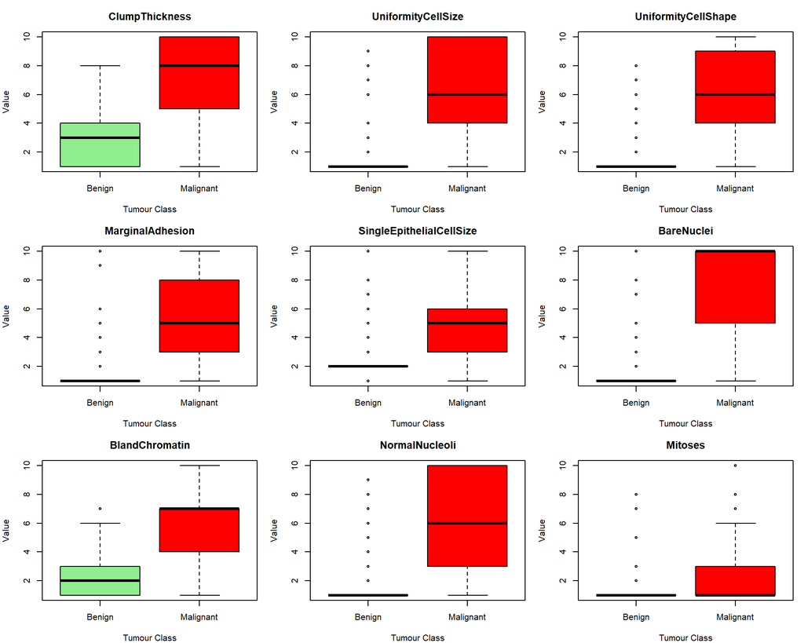

```r
# Select only the nine tumour-related predictor variables
predictor_names <- c(
  "ClumpThickness",
  "UniformityCellSize",
  "UniformityCellShape",
  "MarginalAdhesion",
  "SingleEpithelialCellSize",
  "BareNuclei",
  "BlandChromatin",
  "NormalNucleoli",
  "Mitoses"
)

# Create boxplots comparing each predictor by tumour class
par(mfrow = c(3, 3), mar = c(4, 4, 3, 1))

for (variable in predictor_names) {
  boxplot(
    Cancer[[variable]] ~ Cancer$Class,
    main = variable,
    xlab = "Tumour Class",
    ylab = "Value",
    names = c("Benign", "Malignant"),
    col = c("lightgreen", "red")
  )
}
```

```r
# Reset plotting layout
par(mfrow = c(1, 1))
```

## 3.4 Correlation Analysis

Correlation analysis is used to examine the strength and direction of relationships between the numerical predictor variables. This is useful for identifying predictors that contain similar information and for understanding the structure of the dataset before developing the classification models.

```r
# Select the nine tumour-related predictors
predictor_data <- Cancer[, predictor_names]

# Calculate the correlation matrix
correlation_matrix <- cor(
  predictor_data,
  use = "complete.obs"
)

# Display the correlation matrix
round(correlation_matrix, 2)
```

```
##                          ClumpThickness UniformityCellSize UniformityCellShape
## ClumpThickness                     1.00               0.64                0.65
## UniformityCellSize                 0.64               1.00                0.91
## UniformityCellShape                0.65               0.91                1.00
## MarginalAdhesion                   0.49               0.71                0.69
## SingleEpithelialCellSize           0.52               0.75                0.72
## BareNuclei                         0.59               0.69                0.71
## BlandChromatin                     0.55               0.76                0.74
## NormalNucleoli                     0.53               0.72                0.72
## Mitoses                            0.35               0.46                0.44
##                          MarginalAdhesion SingleEpithelialCellSize BareNuclei
## ClumpThickness                       0.49                     0.52       0.59
## UniformityCellSize                   0.71                     0.75       0.69
## UniformityCellShape                  0.69                     0.72       0.71
## MarginalAdhesion                     1.00                     0.59       0.67
## SingleEpithelialCellSize             0.59                     1.00       0.59
## BareNuclei                           0.67                     0.59       1.00
## BlandChromatin                       0.67                     0.62       0.68
## NormalNucleoli                       0.60                     0.63       0.58
## Mitoses                              0.42                     0.48       0.34
##                          BlandChromatin NormalNucleoli Mitoses
## ClumpThickness                     0.55           0.53    0.35
## UniformityCellSize                 0.76           0.72    0.46
## UniformityCellShape                0.74           0.72    0.44
## MarginalAdhesion                   0.67           0.60    0.42
## SingleEpithelialCellSize           0.62           0.63    0.48
## BareNuclei                         0.68           0.58    0.34
## BlandChromatin                     1.00           0.67    0.35
## NormalNucleoli                     0.67           1.00    0.43
## Mitoses                            0.35           0.43    1.00
```

The correlation matrix provides the Pearson correlation coefficient between each pair of predictor variables. Values close to +1 indicate a strong positive relationship, values close to -1 indicate a strong negative relationship, and values close to 0 indicate a weak linear relationship.

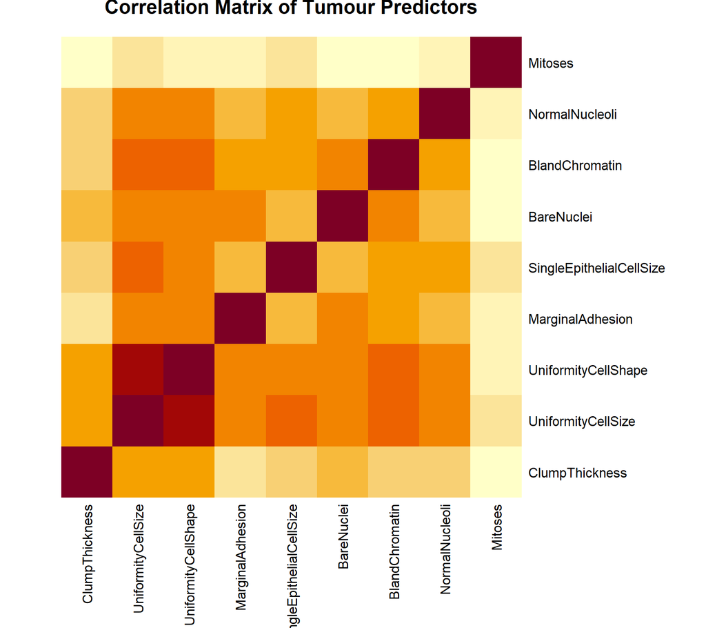

```r
# Visualise the correlation matrix
heatmap(
  correlation_matrix,
  Rowv = NA,
  Colv = NA,
  scale = "none",
  margins = c(10, 10),
  main = "Correlation Matrix of Tumour Predictors"
)
```

```r
# Recalculate the correlation matrix
correlation_matrix <- cor(
  Cancer[, predictor_names],
  use = "complete.obs"
)

# Keep only the upper triangle of the correlation matrix
upper_triangle <- correlation_matrix
upper_triangle[lower.tri(upper_triangle, diag = TRUE)] <- NA

# Convert the matrix into a data frame
correlation_pairs <- as.data.frame(as.table(upper_triangle))

# Remove missing values
correlation_pairs <- correlation_pairs[
  !is.na(correlation_pairs$Freq),
]

# Rename the columns
names(correlation_pairs) <- c(
  "Variable1",
  "Variable2",
  "Correlation"
)

# Sort by absolute correlation strength
correlation_pairs <- correlation_pairs[
  order(abs(correlation_pairs$Correlation), decreasing = TRUE),
]

# Display the 10 strongest relationships
head(correlation_pairs, 10)
```

```
##              Variable1                Variable2 Correlation
## 20  UniformityCellSize      UniformityCellShape   0.9072282
## 56  UniformityCellSize           BlandChromatin   0.7555592
## 38  UniformityCellSize SingleEpithelialCellSize   0.7535440
## 57 UniformityCellShape           BlandChromatin   0.7353435
## 39 UniformityCellShape SingleEpithelialCellSize   0.7224624
## 65  UniformityCellSize           NormalNucleoli   0.7193460
## 66 UniformityCellShape           NormalNucleoli   0.7179634
## 48 UniformityCellShape               BareNuclei   0.7138775
## 29  UniformityCellSize         MarginalAdhesion   0.7069770
## 47  UniformityCellSize               BareNuclei   0.6917088
```

## 3.5 Key Findings from Exploratory Data Analysis

The exploratory data analysis provided several important insights into the breast cancer dataset. The target variable consists of two tumour classes, Benign and Malignant, with the benign class containing more observations than the malignant class. Therefore, the dataset shows some degree of class imbalance, which should be considered when evaluating classification models.

The missing-value analysis identified 16 missing observations in the BareNuclei variable. These observations were removed before the subsequent analysis so that the classification models could be developed using complete cases.

The boxplots showed noticeable differences between benign and malignant tumours for several predictor variables. In particular, variables related to cell uniformity, bare nuclei, bland chromatin and normal nucleoli showed higher values for malignant observations. This suggests that these variables may provide useful information for distinguishing between the two tumour classes.

The correlation analysis also identified several relatively strong positive relationships between the predictor variables. The strongest correlation was approximately 0.91, while several other relationships were above 0.70. This indicates that some predictors contain related information. However, the predictors were retained for the initial modelling stage because each variable represents a different tumour characteristic.

Overall, the exploratory analysis indicates that the dataset contains meaningful patterns that can potentially be used to distinguish benign from malignant tumours. These findings provide a basis for developing and comparing classification models in the next stage of the analysis.

## 4. Classification Analysis

### 4.1 Training and Test Data

The classification analysis aims to predict whether a tumour is benign or malignant using the nine tumour-related predictor variables.

The dataset was divided into training and test sets. The training data was used to develop and tune the models, while the test data was kept separate and used only for final model evaluation. A 70:30 split was used.

```r
# Load required package
library(caret)

# Make sure the target variable is a classification factor
Cancer$Class <- factor(
  Cancer$Class,
  levels = c(2, 4),
  labels = c("Benign", "Malignant")
)

# Select predictors and target
Cancer_model <- Cancer[, c(predictor_names, "Class")]

# Remove observations with missing values
Cancer_model <- Cancer_model[
  complete.cases(Cancer_model),
]

# Confirm that Class is a factor
str(Cancer_model$Class)
```

```
##  Factor w/ 2 levels "Benign","Malignant": 1 1 1 1 1 2 1 1 1 1 ...
```

```r
# Check that there are no missing values
colSums(is.na(Cancer_model))
```

```
##           ClumpThickness       UniformityCellSize      UniformityCellShape
##                        0                        0                        0
##         MarginalAdhesion SingleEpithelialCellSize               BareNuclei
##                        0                        0                        0
##           BlandChromatin           NormalNucleoli                  Mitoses
##                        0                        0                        0
##                    Class
##                        0
```

```r
# Reproducible train-test split
set.seed(123)

train_index <- createDataPartition(
  Cancer_model$Class,
  p = 0.70,
  list = FALSE
)

Cancer_train <- Cancer_model[train_index, ]
Cancer_test <- Cancer_model[-train_index, ]

# Check class distributions
table(Cancer_train$Class)
```

```
##
##    Benign Malignant
##       311       168
```

```r
table(Cancer_test$Class)
```

```
##
##    Benign Malignant
##       133        71
```

### 4.2 Baseline Decision Tree

```r
library(rpart)
library(rpart.plot)

# Fit the baseline decision tree
decision_tree_baseline <- rpart(
  Class ~ .,
  data = Cancer_train[, c(predictor_names, "Class")],
  method = "class"
)

# Display the model summary
decision_tree_baseline
```

```
## n= 479
##
## node), split, n, loss, yval, (yprob)
##       * denotes terminal node
##
##  1) root 479 168 Benign (0.649269311 0.350730689)
##    2) UniformityCellSize< 3.5 329  26 Benign (0.920972644 0.079027356)
##      4) BareNuclei< 2.5 288   2 Benign (0.993055556 0.006944444) *
##      5) BareNuclei>=2.5 41  17 Malignant (0.414634146 0.585365854)
##       10) UniformityCellShape< 2.5 20   5 Benign (0.750000000 0.250000000)
##         20) ClumpThickness< 3.5 12   0 Benign (1.000000000 0.000000000) *
##         21) ClumpThickness>=3.5 8   3 Malignant (0.375000000 0.625000000) *
##       11) UniformityCellShape>=2.5 21   2 Malignant (0.095238095 0.904761905) *
##    3) UniformityCellSize>=3.5 150   8 Malignant (0.053333333 0.946666667) *
```

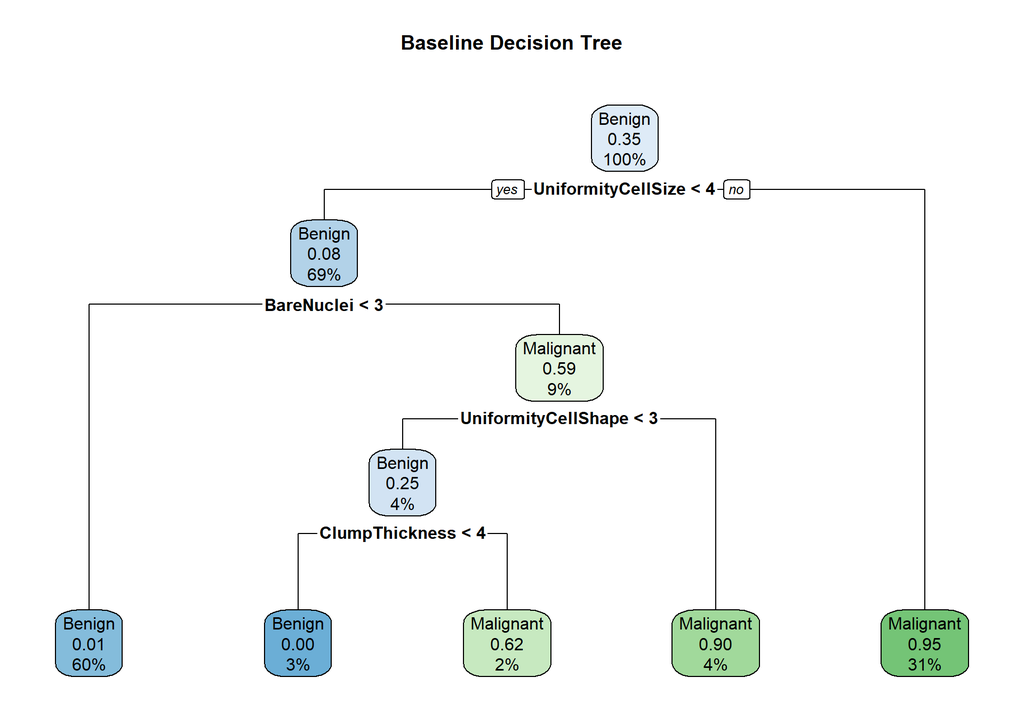

```r
# Plot the baseline decision tree
rpart.plot(
  decision_tree_baseline,
  main = "Baseline Decision Tree"
)
```

### 4.3 Decision Tree Hyperparameter Tuning

The complexity parameter (`cp`) controls the size of the decision tree. A very small value can produce a large tree that may overfit the training data, while a larger value produces a simpler tree.

To identify an appropriate value of `cp`, 10-fold cross-validation was used on the training dataset. The model with the best cross-validated accuracy was selected for final evaluation on the unseen test data.

```r
# Define 10-fold cross-validation
tree_control <- trainControl(
  method = "cv",
  number = 10
)

# Define candidate complexity parameter values
tree_grid <- expand.grid(
  cp = seq(0.001, 0.05, by = 0.002)
)

# Tune the decision tree using cross-validation
decision_tree_tuned <- train(
  Class ~ .,
  data = Cancer_train[, c(predictor_names, "Class")],
  method = "rpart",
  trControl = tree_control,
  tuneGrid = tree_grid
)

# Display the tuning results
decision_tree_tuned
```

```
## CART
##
## 479 samples
##   9 predictor
##   2 classes: 'Benign', 'Malignant'
##
## No pre-processing
## Resampling: Cross-Validated (10 fold)
## Summary of sample sizes: 431, 431, 431, 431, 431, 430, ...
## Resampling results across tuning parameters:
##
##   cp     Accuracy   Kappa
##   0.001  0.9249059  0.8343841
##   0.003  0.9249059  0.8343841
##   0.005  0.9311134  0.8495552
##   0.007  0.9290301  0.8448356
##   0.009  0.9290301  0.8448356
##   0.011  0.9290301  0.8448356
##   0.013  0.9290301  0.8448356
##   0.015  0.9290301  0.8448356
##   0.017  0.9290726  0.8448769
##   0.019  0.9290726  0.8448769
##   0.021  0.9290726  0.8448769
##   0.023  0.9290726  0.8448769
##   0.025  0.9290726  0.8448769
##   0.027  0.9290726  0.8448769
##   0.029  0.9290726  0.8448769
##   0.031  0.9290726  0.8448769
##   0.033  0.9290726  0.8448769
##   0.035  0.9311559  0.8490355
##   0.037  0.9311559  0.8490355
##   0.039  0.9311559  0.8490355
##   0.041  0.9311559  0.8490355
##   0.043  0.9311559  0.8490355
##   0.045  0.9311559  0.8490355
##   0.047  0.9249059  0.8369128
##   0.049  0.9249059  0.8369128
##
## Accuracy was used to select the optimal model using the largest value.
## The final value used for the model was cp = 0.045.
```

```r
# Display the best complexity parameter
decision_tree_tuned$bestTune
```

```
##       cp
## 23 0.045
```

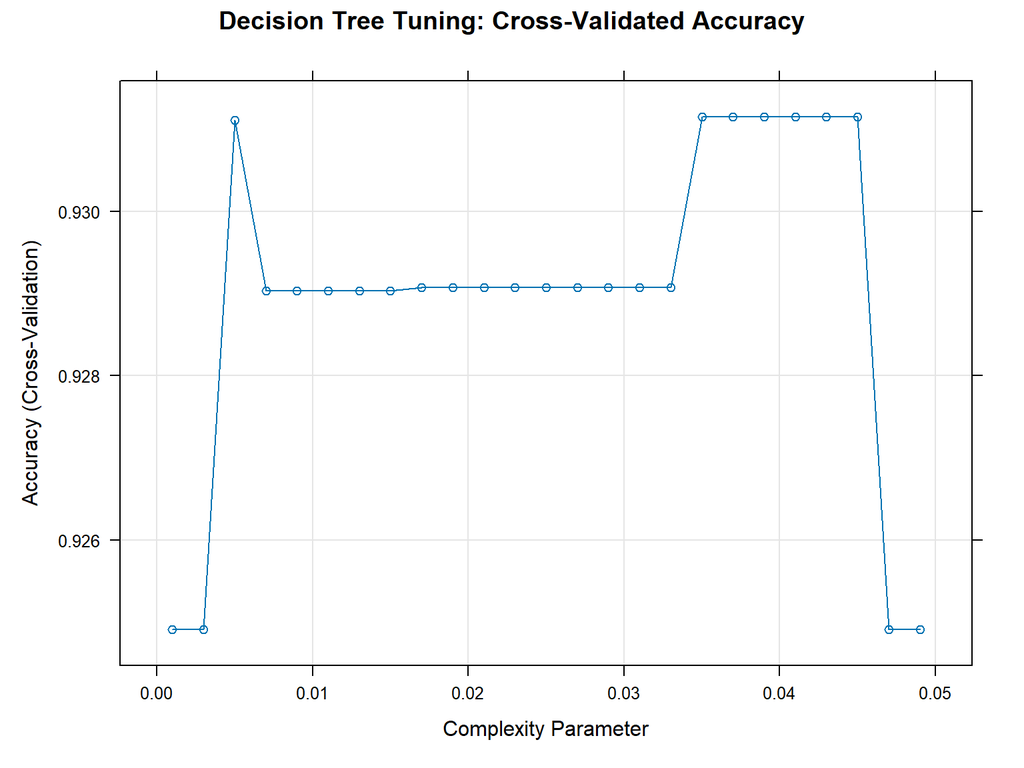

```r
# Plot cross-validation accuracy for different cp values
plot(
  decision_tree_tuned,
  main = "Decision Tree Tuning: Cross-Validated Accuracy"
)
```

### 4.4 Final Tuned Decision Tree

The complexity parameter producing the highest cross-validated performance was selected as the final tuning parameter.

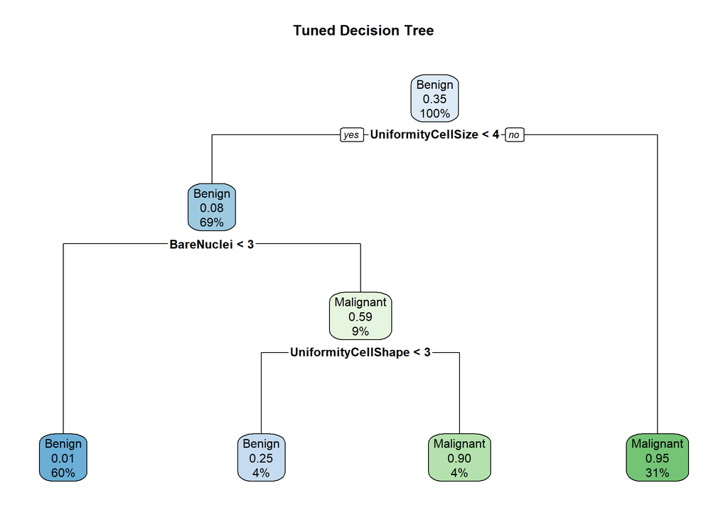

```r
# Plot the final tuned decision tree
rpart.plot(
  decision_tree_tuned$finalModel,
  main = "Tuned Decision Tree"
)
```

### 4.5 Decision Tree Evaluation

The final tuned decision tree was evaluated using the independent test dataset. Accuracy alone can be misleading when the class distribution is not perfectly balanced, so sensitivity, specificity, precision and F1-score were also considered.

```r
# Generate class predictions from the tuned tree
tree_predictions <- predict(
  decision_tree_tuned,
  newdata = Cancer_test,
  type = "raw"
)

# Check prediction levels
levels(tree_predictions)
```

```
## [1] "Benign"    "Malignant"
```

```r
# Check actual class levels
levels(Cancer_test$Class)
```

```
## [1] "Benign"    "Malignant"
```

```r
# Display prediction counts
table(tree_predictions)
```

```
## tree_predictions
##    Benign Malignant
##       131        73
```

```r
# Display actual test-set counts
table(Cancer_test$Class)
```

```
##
##    Benign Malignant
##       133        71
```

```r
# Confusion matrix
tree_confusion <- confusionMatrix(
  data = tree_predictions,
  reference = Cancer_test$Class,
  positive = "Malignant"
)

tree_confusion
```

```
## Confusion Matrix and Statistics
##
##            Reference
## Prediction  Benign Malignant
##   Benign       129         2
##   Malignant      4        69
##
##                Accuracy : 0.9706
##                  95% CI : (0.9371, 0.9891)
##     No Information Rate : 0.652
##     P-Value [Acc > NIR] : <2e-16
##
##                   Kappa : 0.9356
##
##  Mcnemar's Test P-Value : 0.6831
##
##             Sensitivity : 0.9718
##             Specificity : 0.9699
##          Pos Pred Value : 0.9452
##          Neg Pred Value : 0.9847
##              Prevalence : 0.3480
##          Detection Rate : 0.3382
##    Detection Prevalence : 0.3578
##       Balanced Accuracy : 0.9709
##
##        'Positive' Class : Malignant
##
```

```r
# Extract precision and recall
tree_precision <- tree_confusion$byClass["Pos Pred Value"]
tree_recall <- tree_confusion$byClass["Sensitivity"]

# Calculate F1-score
tree_f1 <- 2 * (
  tree_precision * tree_recall
) / (
  tree_precision + tree_recall
)

tree_f1
```

```
## Pos Pred Value
##      0.9583333
```

### 4.6 Interpretation of Decision Tree Results

The tuned Decision Tree achieved an accuracy of 97.06% on the independent test dataset. The confusion matrix shows that 129 benign tumours and 69 malignant tumours were correctly classified. Two malignant tumours were incorrectly classified as benign, while four benign tumours were incorrectly classified as malignant.

The model achieved a sensitivity of 97.18%, meaning that it correctly identified approximately 97% of the malignant tumours. Its specificity was 96.99%, indicating that approximately 97% of benign tumours were correctly identified. The positive predictive value was 94.52%, while the F1-score was 95.83%, demonstrating a strong balance between precision and sensitivity.

The balanced accuracy was 97.09%, which is close to the overall accuracy. This suggests that the model performs consistently across the two tumour classes despite the difference in class frequencies. Overall, the tuned Decision Tree demonstrated strong predictive performance on the unseen test data.

### 4.7 k-Nearest Neighbours (kNN)

The k-Nearest Neighbours (kNN) algorithm classifies an observation based on the classes of its nearest observations in the feature space. The value of `k` determines the number of neighbouring observations considered when making a prediction.

Because kNN is a distance-based algorithm, the predictor variables were standardised before modelling. This prevents variables with larger numerical scales from having a disproportionate influence on the distance calculation.

```r
# Load required packages
library(caret)

# Set seed for reproducibility
set.seed(123)

# Define 10-fold cross-validation
knn_control <- trainControl(
  method = "cv",
  number = 10
)

# Define candidate values of k
knn_grid <- expand.grid(
  k = seq(1, 25, by = 2)
)

# Tune kNN using cross-validation
knn_tuned <- train(
  Class ~ .,
  data = Cancer_train,
  method = "knn",
  trControl = knn_control,
  preProcess = c("center", "scale"),
  tuneGrid = knn_grid
)

# Display tuning results
knn_tuned
```

```
## k-Nearest Neighbors
##
## 479 samples
##   9 predictor
##   2 classes: 'Benign', 'Malignant'
##
## Pre-processing: centered (9), scaled (9)
## Resampling: Cross-Validated (10 fold)
## Summary of sample sizes: 430, 431, 431, 431, 432, 431, ...
## Resampling results across tuning parameters:
##
##   k   Accuracy   Kappa
##    1  0.9540283  0.8971379
##    3  0.9623634  0.9169204
##    5  0.9602801  0.9121757
##    7  0.9624077  0.9169842
##    9  0.9665744  0.9262149
##   11  0.9666612  0.9263139
##   13  0.9666169  0.9259375
##   15  0.9666169  0.9265249
##   17  0.9687446  0.9310553
##   19  0.9644893  0.9214071
##   21  0.9666169  0.9259375
##   23  0.9645336  0.9211995
##   25  0.9603226  0.9119278
##
## Accuracy was used to select the optimal model using the largest value.
## The final value used for the model was k = 17.
```

```r
# Display the best value of k
knn_tuned$bestTune
```

```
##    k
## 9 17
```

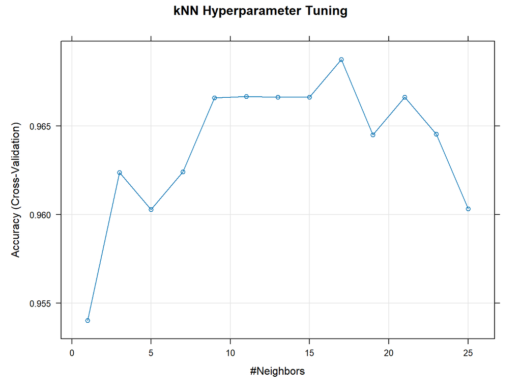

```r
# Plot cross-validated accuracy for different k values
plot(
  knn_tuned,
  main = "kNN Hyperparameter Tuning"
)
```

### 4.8 kNN Evaluation

The tuned kNN model was evaluated using the independent test dataset. The test data was not used during hyperparameter tuning, allowing the final performance to be assessed on previously unseen observations.

```r
# Generate predictions on the test dataset
knn_predictions <- predict(
  knn_tuned,
  newdata = Cancer_test
)

# Ensure prediction and reference have the same factor levels
knn_predictions <- factor(
  knn_predictions,
  levels = levels(Cancer_test$Class)
)

# Generate confusion matrix
knn_confusion <- confusionMatrix(
  data = knn_predictions,
  reference = Cancer_test$Class,
  positive = "Malignant"
)

# Display results
knn_confusion
```

```
## Confusion Matrix and Statistics
##
##            Reference
## Prediction  Benign Malignant
##   Benign       130         2
##   Malignant      3        69
##
##                Accuracy : 0.9755
##                  95% CI : (0.9437, 0.992)
##     No Information Rate : 0.652
##     P-Value [Acc > NIR] : <2e-16
##
##                   Kappa : 0.9462
##
##  Mcnemar's Test P-Value : 1
##
##             Sensitivity : 0.9718
##             Specificity : 0.9774
##          Pos Pred Value : 0.9583
##          Neg Pred Value : 0.9848
##              Prevalence : 0.3480
##          Detection Rate : 0.3382
##    Detection Prevalence : 0.3529
##       Balanced Accuracy : 0.9746
##
##        'Positive' Class : Malignant
##
```

```r
# Extract precision and sensitivity
knn_precision <- knn_confusion$byClass["Pos Pred Value"]
knn_recall <- knn_confusion$byClass["Sensitivity"]

# Calculate F1-score
knn_f1 <- 2 * (
  knn_precision * knn_recall
) / (
  knn_precision + knn_recall
)

knn_f1
```

```
## Pos Pred Value
##       0.965035
```

### 4.9 Interpretation of kNN Results

The kNN model was tuned using 10-fold cross-validation across multiple values of the hyperparameter k. The optimal value selected during the tuning process was k = 17.

When evaluated on the independent test dataset, the tuned kNN model achieved an accuracy of 97.55%. The model correctly classified 130 benign and 69 malignant tumours. Two malignant tumours were incorrectly classified as benign, while three benign tumours were incorrectly classified as malignant.

The model achieved a sensitivity of 97.18%, indicating that it correctly identified approximately 97% of the malignant tumours. Specificity was 97.74%, indicating strong performance in identifying benign tumours. The positive predictive value was 95.83%, while the balanced accuracy was 97.46%.

Overall, the tuned kNN model demonstrated strong predictive performance on the independent test dataset. The selection of k = 17 through cross-validation provides a data-driven choice of the neighbourhood size rather than relying on an arbitrarily selected value.

### 4.10 Comparison of Classification Models

The tuned Decision Tree and tuned kNN models were evaluated on the same independent test dataset. Their performance was compared using accuracy, sensitivity, specificity, precision, F1-score and balanced accuracy.

```r
# Extract Decision Tree metrics
tree_metrics <- data.frame(
  Model = "Decision Tree",
  Accuracy = as.numeric(tree_confusion$overall["Accuracy"]),
  Sensitivity = as.numeric(tree_confusion$byClass["Sensitivity"]),
  Specificity = as.numeric(tree_confusion$byClass["Specificity"]),
  Precision = as.numeric(tree_confusion$byClass["Pos Pred Value"]),
  F1_Score = as.numeric(tree_f1),
  Balanced_Accuracy = as.numeric(tree_confusion$byClass["Balanced Accuracy"])
)

# Extract kNN metrics
knn_metrics <- data.frame(
  Model = "kNN",
  Accuracy = as.numeric(knn_confusion$overall["Accuracy"]),
  Sensitivity = as.numeric(knn_confusion$byClass["Sensitivity"]),
  Specificity = as.numeric(knn_confusion$byClass["Specificity"]),
  Precision = as.numeric(knn_confusion$byClass["Pos Pred Value"]),
  F1_Score = as.numeric(knn_f1),
  Balanced_Accuracy = as.numeric(knn_confusion$byClass["Balanced Accuracy"])
)

# Combine the results
model_comparison <- rbind(
  tree_metrics,
  knn_metrics
)

# Display results as percentages
model_comparison[, -1] <- round(
  model_comparison[, -1] * 100,
  2
)

model_comparison
```

```
##           Model Accuracy Sensitivity Specificity Precision F1_Score
## 1 Decision Tree    97.06       97.18       96.99     94.52    95.83
## 2           kNN    97.55       97.18       97.74     95.83    96.50
##   Balanced_Accuracy
## 1             97.09
## 2             97.46
```

The comparison shows that both models achieved strong performance on the independent test dataset. The tuned kNN model achieved slightly higher accuracy (97.55%) than the tuned Decision Tree (97.06%). kNN also achieved higher specificity, precision, F1-score and balanced accuracy, while both models achieved the same sensitivity of 97.18%.

Based on these results, kNN was selected as the preferred classification model for this dataset. However, the difference in performance between the two models was relatively small, indicating that both approaches were effective at distinguishing between benign and malignant tumours.

## Reflection

### Reflection on the Classification Analysis

This classification analysis provided an opportunity to apply supervised machine learning techniques to a binary classification problem involving benign and malignant tumours. The analysis followed a structured workflow, beginning with the separation of the data into training and independent testing datasets. A baseline Decision Tree was first developed to establish an initial benchmark, followed by hyperparameter tuning to improve its performance. A final tuned Decision Tree was then evaluated and interpreted. A k-Nearest Neighbours (kNN) model was also developed and evaluated, allowing the performance of two different classification approaches to be compared.

One of the main successes of the analysis was the use of an independent test dataset to evaluate the final models. This helped provide a more realistic assessment of how the models would perform on unseen observations rather than evaluating them only on the data used for training. Hyperparameter tuning was also an important part of the analysis because it demonstrated that model performance can be influenced by the configuration of a predictive algorithm rather than only by the choice of algorithm itself.

A challenge during the analysis was understanding the differences between the evaluation measures used for classification. Accuracy alone does not provide a complete picture of model performance, particularly when the consequences of false positive and false negative predictions may differ. Therefore, sensitivity, specificity, precision, F1-score, and balanced accuracy were considered when comparing the Decision Tree and kNN models. This provided a more comprehensive evaluation of the classifiers.

Another important decision was to tune the Decision Tree rather than relying only on the baseline model. The tuning process allowed the model configuration to be adjusted systematically and provided a basis for comparing the tuned model against the initial baseline. The kNN model provided a useful comparison because it uses a fundamentally different approach from a Decision Tree. This helped determine whether the observed predictive performance was specific to one modelling technique or consistent across different approaches.

The final comparison showed that both models performed strongly on the independent test dataset. The tuned kNN model achieved an accuracy of **97.55%**, compared with **97.06%** for the tuned Decision Tree. kNN also achieved higher specificity, precision, F1-score, and balanced accuracy, while both models achieved the same sensitivity of **97.18%**. Based on these results, kNN was selected as the preferred model for this dataset. However, the difference between the models was relatively small, demonstrating that both methods were effective at distinguishing between benign and malignant tumours.

### Use of Generative AI

Generative AI was used as a supporting tool during the classification analysis. It helped explain machine learning concepts, clarify the purpose of different classification methods and evaluation metrics, and provide guidance when developing and organising the R code. It was also useful for understanding concepts such as hyperparameter tuning, confusion matrices, sensitivity, specificity, precision, F1-score, and balanced accuracy.

Generative AI was also used to help troubleshoot coding and R Markdown issues and to interpret model outputs in the context of the analysis. However, the actual models were trained and evaluated using the dataset in R, and the resulting outputs were checked before conclusions were made. The final model comparison was therefore based on the actual test-set results rather than on assumptions or AI-generated values.

### Important Decisions and Their Effects

One important decision was to evaluate the models using an independent test dataset. This reduced the risk of judging model performance solely from the training data and provided evidence of how well the models generalised to unseen observations.

Another important decision was to tune the Decision Tree before comparing it with kNN. This provided a fairer comparison because the Decision Tree was not evaluated only in its initial configuration. The use of several evaluation metrics also affected the final decision. Although both models achieved high accuracy, kNN consistently performed slightly better across several measures, leading to its selection as the preferred model.

### Future Work

The classification analysis could be extended in several ways. First, additional classification algorithms could be investigated, such as Random Forest, Support Vector Machines, or other ensemble methods. Comparing a wider range of algorithms could determine whether the small performance difference between kNN and the Decision Tree could be improved further.

Second, cross-validation could be used during model tuning and evaluation instead of relying primarily on a single train/test split. This could provide a more robust estimate of model performance across different subsets of the data.

Another possible area of future work would be feature selection and feature engineering. Investigating which variables contribute most strongly to classification performance could potentially simplify the model while maintaining high predictive accuracy.

Finally, because the classification problem involves distinguishing between benign and malignant tumours, future analysis should consider the practical consequences of different types of classification errors. Although both models achieved the same sensitivity of 97.18%, further work could investigate whether optimising specifically for sensitivity or reducing false-negative predictions would be preferable depending on the intended application.